# Script 2

Yanming Di

2018-05-12

(Read also Chapter 6 of Kuehl)

# 1. Design: completely randomized two-factor design

## Experimental units:

24 specimens

## Treatments:

Two factors:

1. “compaction method” with four levels: static pressure, regular kneading, low kneading, and very low kneading.
2. “aggregate type” with two levels: basalt or siliceous(silicious) rock

## Assign treatments to experimental units:

We use the concrete data as an example (Kuehl, pp. 175-190). “Three replicate specimen of the asphalt concrete were constructed and tested for each of the eight treatment combinations. The 24 specimens were prepared and tested in random order for a completely randomized design”.

How do we randomly the assign the eight treatment combinations to the experimental units? One possible way:

```r
## List all treatment combinations
method = c("static pressure", "regular kneading", "low kneading", "very low kneading");
type = c("basalt", "silicious rock");
treatments = as.vector(outer(method, type, paste, sep=", "));
treatments
```

```
## [1] "static pressure, basalt"           "regular kneading, basalt"
## [3] "low kneading, basalt"              "very low kneading, basalt"
## [5] "static pressure, silicious rock"   "regular kneading, silicious rock"
## [7] "low kneading, silicious rock"      "very low kneading, silicious rock"
```

```r
## Set a random number seed to make the results reproducible
set.seed(999);

## Repeat each treatment 3 times and arrange the result in random order
assignment = data.frame(specimen=1:24, treatment=sample(rep(treatments, each=3)))
assignment
```

```
##    specimen                         treatment
## 1         1         very low kneading, basalt
## 2         2   static pressure, silicious rock
## 3         3           static pressure, basalt
## 4         4  regular kneading, silicious rock
## 5         5  regular kneading, silicious rock
## 6         6 very low kneading, silicious rock
## 7         7         very low kneading, basalt
## 8         8           static pressure, basalt
## 9         9              low kneading, basalt
## 10       10 very low kneading, silicious rock
## 11       11          regular kneading, basalt
## 12       12              low kneading, basalt
## 13       13           static pressure, basalt
## 14       14      low kneading, silicious rock
## 15       15  regular kneading, silicious rock
## 16       16   static pressure, silicious rock
## 17       17   static pressure, silicious rock
## 18       18          regular kneading, basalt
## 19       19         very low kneading, basalt
## 20       20      low kneading, silicious rock
## 21       21 very low kneading, silicious rock
## 22       22              low kneading, basalt
## 23       23      low kneading, silicious rock
## 24       24          regular kneading, basalt
```

Alternatively, we can randomly permute the experiment units (specimens) and then, after random permuation, assign treatment 1 to the first three specimens, treatment 2 to the next three specimens.

In R, more specifically, we can number the specimens by 1, 2, …, 24 and then permute the numbers 1, 2, …,24. After permuation, we assign treatment 1 to the first three specimens, treatment 2 to the next three specimens.

```r
id.eu = sample(1:24);
assignment = data.frame(specimen = id.eu, treatment = rep(treatments, each=3));
assignment
```

```
##    specimen                         treatment
## 1        20           static pressure, basalt
## 2        19           static pressure, basalt
## 3        13           static pressure, basalt
## 4        14          regular kneading, basalt
## 5        17          regular kneading, basalt
## 6         9          regular kneading, basalt
## 7         2              low kneading, basalt
## 8         4              low kneading, basalt
## 9        23              low kneading, basalt
## 10       16         very low kneading, basalt
## 11        8         very low kneading, basalt
## 12       12         very low kneading, basalt
## 13       10   static pressure, silicious rock
## 14       15   static pressure, silicious rock
## 15        1   static pressure, silicious rock
## 16       24  regular kneading, silicious rock
## 17       22  regular kneading, silicious rock
## 18        6  regular kneading, silicious rock
## 19        5      low kneading, silicious rock
## 20        3      low kneading, silicious rock
## 21       18      low kneading, silicious rock
## 22       21 very low kneading, silicious rock
## 23       11 very low kneading, silicious rock
## 24        7 very low kneading, silicious rock
```

```r
## rm(method, type, treatments, assignment);
```

## Measurements

Tensile strength measurements (psi) on the 24 specimens.

# 2. Analyses and graphs for the two-way layout

## Load the data

> method: 2 Regular, 3 Low, 4 Very Low, 1 Static

> type: 1 Basalt, 2 Silicious

```r
## Clean the R environment
rm(list=ls());

concrete <- read.table("../data/concrete.txt", header=TRUE)
attach(concrete)

## Create factors for method (compaction method) and type (aggregate type).
## method.f <- as.factor(method)
## type.f <- as.factor(type)

## The above code (commented out part) will work fine, but we will do somthing slightly different here.

## We will convert the numberical coding of the factor levels to strings. There are pros and cons
method.levels = c("Static", "Regular", "Low", "Very Low")
method.f = factor(method.levels[method], levels=method.levels);

type.levels = c("Basalt", "Siliciuos");
type.f = factor(type.levels[type], levels=type.levels);

## One benefit is that it makes the results more readable (compare "concrete" (numerical coding) and "bf" (string coding) to Table 6.3 on page 181)
df = data.frame(method=method.f, type=type.f, strength=strength)
concrete
```

```
##    method type strength
## 1       2    1      126
## 2       2    1      128
## 3       2    1      133
## 4       2    2      107
## 5       2    2      110
## 6       2    2      116
## 7       3    1       93
## 8       3    1      101
## 9       3    1       98
## 10      3    2       63
## 11      3    2       60
## 12      3    2       59
## 13      4    1       56
## 14      4    1       59
## 15      4    1       57
## 16      4    2       40
## 17      4    2       41
## 18      4    2       44
## 19      1    1       68
## 20      1    1       63
## 21      1    1       65
## 22      1    2       71
## 23      1    2       66
## 24      1    2       66
```

```r
df
```

```
##      method      type strength
## 1   Regular    Basalt      126
## 2   Regular    Basalt      128
## 3   Regular    Basalt      133
## 4   Regular Siliciuos      107
## 5   Regular Siliciuos      110
## 6   Regular Siliciuos      116
## 7       Low    Basalt       93
## 8       Low    Basalt      101
## 9       Low    Basalt       98
## 10      Low Siliciuos       63
## 11      Low Siliciuos       60
## 12      Low Siliciuos       59
## 13 Very Low    Basalt       56
## 14 Very Low    Basalt       59
## 15 Very Low    Basalt       57
## 16 Very Low Siliciuos       40
## 17 Very Low Siliciuos       41
## 18 Very Low Siliciuos       44
## 19   Static    Basalt       68
## 20   Static    Basalt       63
## 21   Static    Basalt       65
## 22   Static Siliciuos       71
## 23   Static Siliciuos       66
## 24   Static Siliciuos       66
```

WARNING: potential issue with using strings instead numbers to code the factor levels in R:

```r
## We can save the above for future use if we want. (You need to adjust the directory name to run it on your own computer.)

file.csv = "../data/concretre.csv";
write.csv(df, file.csv, quote=FALSE, row.names=FALSE)

## Later we can read it as
df1 = read.csv(file.csv, header=TRUE)

## But the downside is when you read the data back, "Static" is no longer corresponds to level 1 by default.
df$method
```

```
##  [1] Regular  Regular  Regular  Regular  Regular  Regular  Low
##  [8] Low      Low      Low      Low      Low      Very Low Very Low
## [15] Very Low Very Low Very Low Very Low Static   Static   Static
## [22] Static   Static   Static
## Levels: Static Regular Low Very Low
```

```r
df1$method
```

```
##  [1] Regular  Regular  Regular  Regular  Regular  Regular  Low
##  [8] Low      Low      Low      Low      Low      Very Low Very Low
## [15] Very Low Very Low Very Low Very Low Static   Static   Static
## [22] Static   Static   Static
## Levels: Low Regular Static Very Low
```

You can avoid this by using R’s intrinsic data structure, but we will not go there now. Just remember to be careful when using factor variables in R.

## Look at the data and do some summary statistics

```r
str(df)
```

```
## 'data.frame':    24 obs. of  3 variables:
##  $ method  : Factor w/ 4 levels "Static","Regular",..: 2 2 2 2 2 2 3 3 3 3 ...
##  $ type    : Factor w/ 2 levels "Basalt","Siliciuos": 1 1 1 2 2 2 1 1 1 2 ...
##  $ strength: int  126 128 133 107 110 116 93 101 98 63 ...
```

```r
df
```

```
##      method      type strength
## 1   Regular    Basalt      126
## 2   Regular    Basalt      128
## 3   Regular    Basalt      133
## 4   Regular Siliciuos      107
## 5   Regular Siliciuos      110
## 6   Regular Siliciuos      116
## 7       Low    Basalt       93
## 8       Low    Basalt      101
## 9       Low    Basalt       98
## 10      Low Siliciuos       63
## 11      Low Siliciuos       60
## 12      Low Siliciuos       59
## 13 Very Low    Basalt       56
## 14 Very Low    Basalt       59
## 15 Very Low    Basalt       57
## 16 Very Low Siliciuos       40
## 17 Very Low Siliciuos       41
## 18 Very Low Siliciuos       44
## 19   Static    Basalt       68
## 20   Static    Basalt       63
## 21   Static    Basalt       65
## 22   Static Siliciuos       71
## 23   Static Siliciuos       66
## 24   Static Siliciuos       66
```

Get marginal means for the different types, and for the different methods.

```r
tapply(strength, type.f, "mean")
```

```
##    Basalt Siliciuos
##     87.25     70.25
```

```r
tapply(strength, method.f, "mean")
```

```
##   Static  Regular      Low Very Low
##     66.5    120.0     79.0     49.5
```

Get cell means (i.e., means for every combination of type and method).

```r
tapply(strength, list(type.f,method.f), "mean")
```

```
##             Static Regular      Low Very Low
## Basalt    65.33333     129 97.33333 57.33333
## Siliciuos 67.66667     111 60.66667 41.66667
```

## Plot the data

Use the function `interaction` or “:” in R to get all combined factor levels:

```r
f = interaction(type.f, method.f);
f
```

```
##  [1] Basalt.Regular     Basalt.Regular     Basalt.Regular
##  [4] Siliciuos.Regular  Siliciuos.Regular  Siliciuos.Regular
##  [7] Basalt.Low         Basalt.Low         Basalt.Low
## [10] Siliciuos.Low      Siliciuos.Low      Siliciuos.Low
## [13] Basalt.Very Low    Basalt.Very Low    Basalt.Very Low
## [16] Siliciuos.Very Low Siliciuos.Very Low Siliciuos.Very Low
## [19] Basalt.Static      Basalt.Static      Basalt.Static
## [22] Siliciuos.Static   Siliciuos.Static   Siliciuos.Static
## 8 Levels: Basalt.Static Siliciuos.Static ... Siliciuos.Very Low
```

```r
## By default, the combined levels are ordered so the level of the first factor varies fastest
levels(f);
```

```
## [1] "Basalt.Static"      "Siliciuos.Static"   "Basalt.Regular"
## [4] "Siliciuos.Regular"  "Basalt.Low"         "Siliciuos.Low"
## [7] "Basalt.Very Low"    "Siliciuos.Very Low"
```

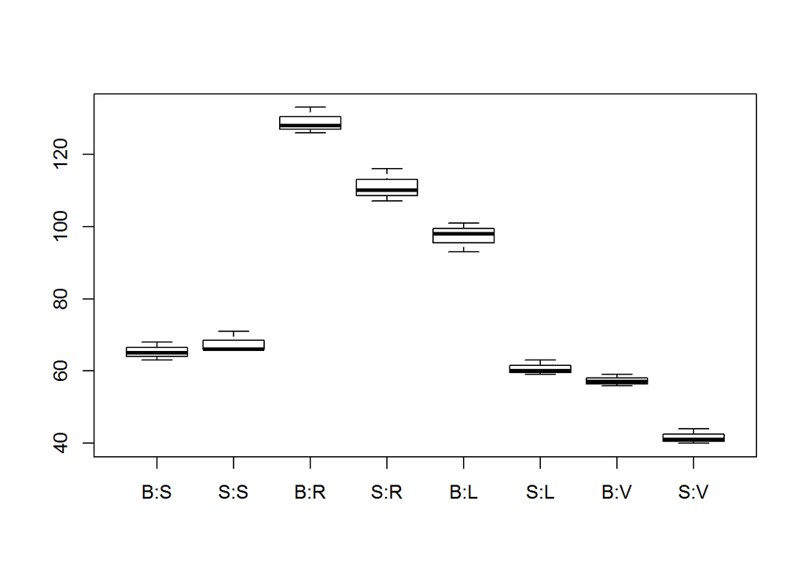

```r
## Box plots for all treatments (i.e., all combined factor levels)

## The names for the combinated factor levels become too long, we can give shorter names when calling the boxplot function (make sure the short names match the factor levels)
names = c("B:S", "S:S", "B:R", "S:R", "B:L", "S:L", "B:V", "S:V");
boxplot(strength ~ f, names=names);
```

```r
## If we want the levels of the last factor vary fastest, we set `lex.order=TRUE`
f = interaction(type.f, method.f, lex.order = TRUE);
levels(f);
```

```
## [1] "Basalt.Static"      "Basalt.Regular"     "Basalt.Low"
## [4] "Basalt.Very Low"    "Siliciuos.Static"   "Siliciuos.Regular"
## [7] "Siliciuos.Low"      "Siliciuos.Very Low"
```

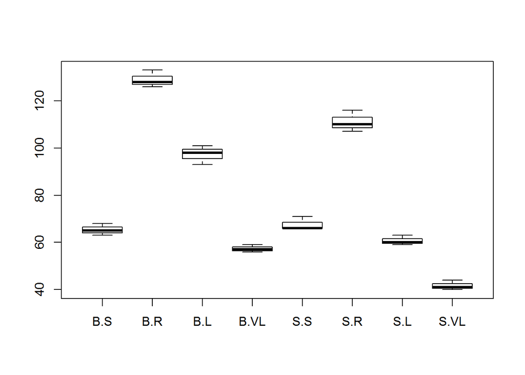

```r
## Another way to get the short names: we remove all lower-case letters and spaces from the long names
names= gsub("[a-z]|[ ]", "", levels(f));
boxplot(strength ~ f, names=names);
```

Earlier, I used `strength ~ type.f:method.f` in the `boxplot` function to show the box plots for all groups. It will also work, but you want to pay attention to how the combined factor levels are arranged on the x-axis:

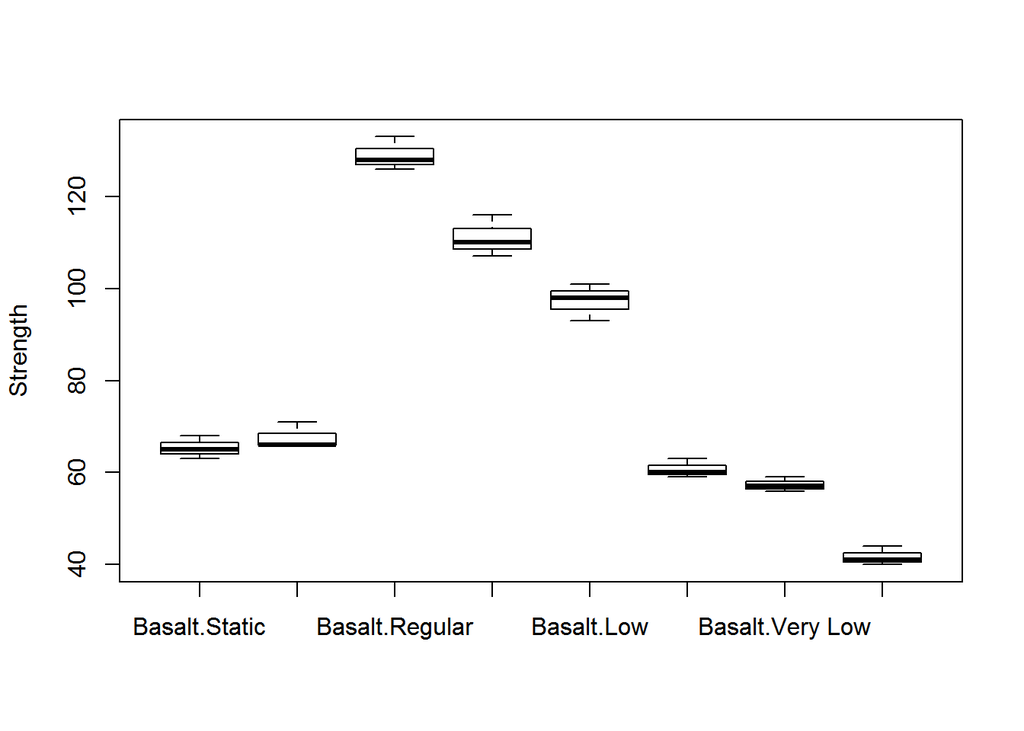

```r
## Not recommeded!
boxplot(strength ~ type.f:method.f, ylab="Strength");
```

`type.f:method.f` will combine the two factor vectors into a new factor vector with levels being all factor level combination. *** Unfortunately, if you list the levels of `type.f:method.f`, you will see that the levels are arranged differently as the way they are arranged on the x-axis of the side-by-side box plots.***

```r
## Note that the levels on the x-axis are arranged different from
levels(type.f:method.f)
```

```
## [1] "Basalt:Static"      "Basalt:Regular"     "Basalt:Low"
## [4] "Basalt:Very Low"    "Siliciuos:Static"   "Siliciuos:Regular"
## [7] "Siliciuos:Low"      "Siliciuos:Very Low"
```

For this reason, avoid using `strength~type.f:method.f` directly in the boxplot function call. Consider the following alternative:

```r
## Recommended:
f = type.f:method.f;
levels(f);
```

```
## [1] "Basalt:Static"      "Basalt:Regular"     "Basalt:Low"
## [4] "Basalt:Very Low"    "Siliciuos:Static"   "Siliciuos:Regular"
## [7] "Siliciuos:Low"      "Siliciuos:Very Low"
```

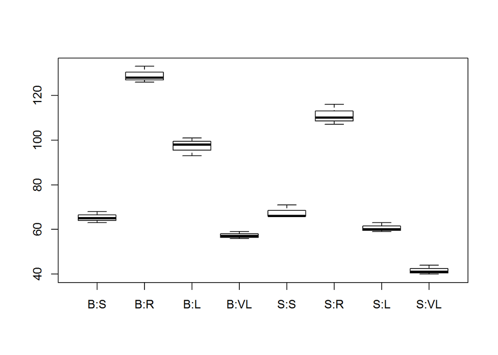

```r
names= gsub("[a-z]|[ ]", "", levels(f));
boxplot(strength~f, names=names);
```

```r
f = method.f:type.f;
levels(f);
```

```
## [1] "Static:Basalt"      "Static:Siliciuos"   "Regular:Basalt"
## [4] "Regular:Siliciuos"  "Low:Basalt"         "Low:Siliciuos"
## [7] "Very Low:Basalt"    "Very Low:Siliciuos"
```

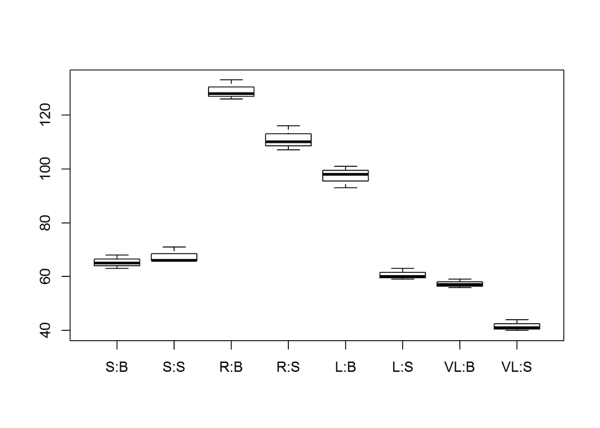

```r
names= gsub("[a-z]|[ ]", "", levels(f));
boxplot(strength~f, names=names);
```

Interaction plots:

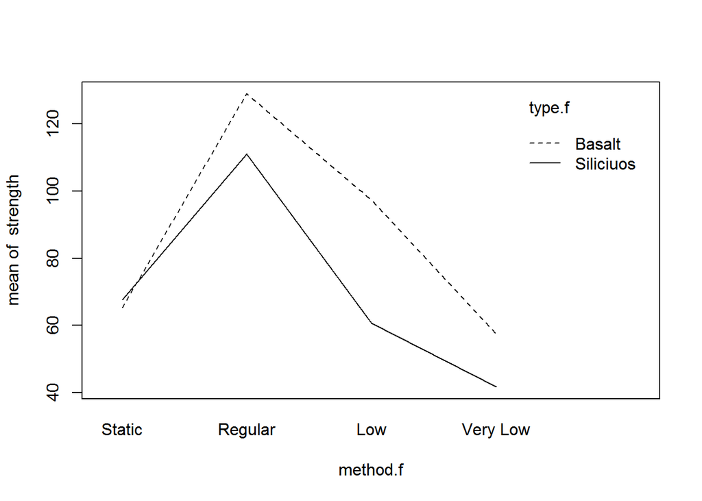

```r
## Use method as x-axis
interaction.plot(method.f, type.f, strength)
```

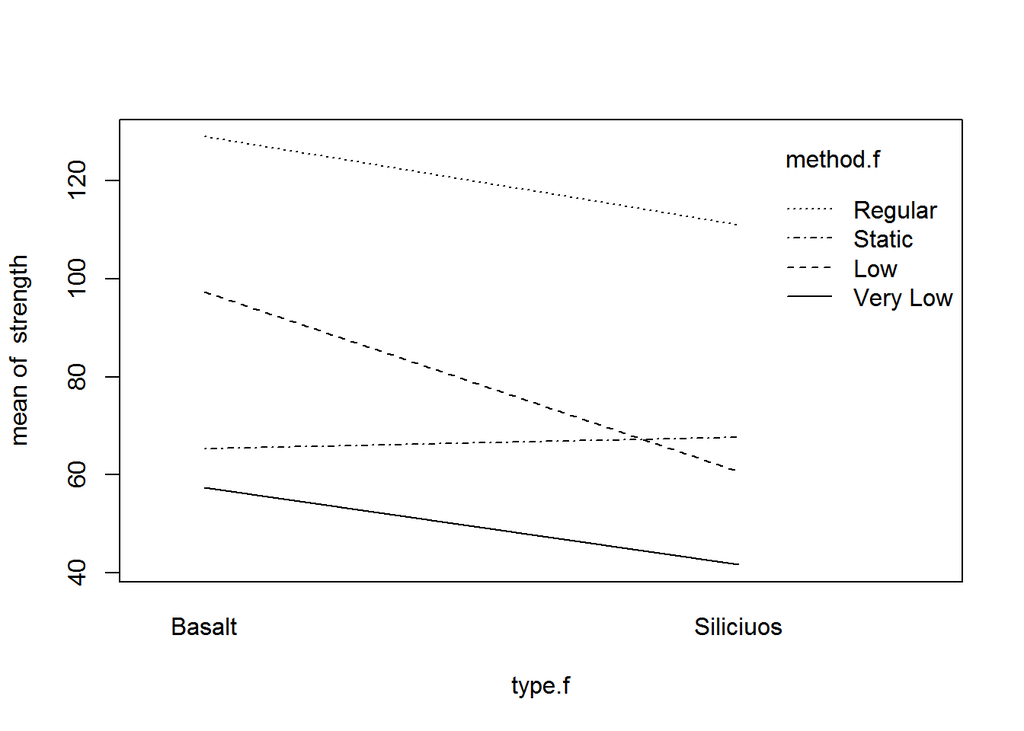

```r
## Use type as x-axis
interaction.plot(type.f, method.f, strength)
```

## Fit the two-way ANOVA model.

The following two uses of ‘lm’ are equivalent.

```r
m1 <- lm(strength ~ method.f*type.f)
m2 <- lm(strength ~ method.f + type.f + method.f:type.f)
m1
```

```
##
## Call:
## lm(formula = strength ~ method.f * type.f)
##
## Coefficients:
##                      (Intercept)                   method.fRegular
##                           65.333                            63.667
##                      method.fLow                  method.fVery Low
##                           32.000                            -8.000
##                  type.fSiliciuos   method.fRegular:type.fSiliciuos
##                            2.333                           -20.333
##      method.fLow:type.fSiliciuos  method.fVery Low:type.fSiliciuos
##                          -39.000                           -18.000
```

```r
m2
```

```
##
## Call:
## lm(formula = strength ~ method.f + type.f + method.f:type.f)
##
## Coefficients:
##                      (Intercept)                   method.fRegular
##                           65.333                            63.667
##                      method.fLow                  method.fVery Low
##                           32.000                            -8.000
##                  type.fSiliciuos   method.fRegular:type.fSiliciuos
##                            2.333                           -20.333
##      method.fLow:type.fSiliciuos  method.fVery Low:type.fSiliciuos
##                          -39.000                           -18.000
```

Study the following ANOVA table and see what correspond to SSA, SSB, SSAB and SSE:

```r
anova(m1)
```

```
## Analysis of Variance Table
##
## Response: strength
##                 Df Sum Sq Mean Sq F value    Pr(>F)
## method.f         3  16244  5414.5 569.947 < 2.2e-16 ***
## type.f           1   1734  1734.0 182.526 3.628e-10 ***
## method.f:type.f  3   1145   381.7  40.175 1.124e-07 ***
## Residuals       16    152     9.5
## ---
## Signif. codes:  0 '***' 0.001 '**' 0.01 '*' 0.05 '.' 0.1 ' ' 1
```

In this balanced design, it does not matter whether we put `type.f` before or after `method.f` in the model formula.

```r
m3 = lm(strength ~ type.f + method.f + method.f:type.f)
anova(m3)
```

```
## Analysis of Variance Table
##
## Response: strength
##                 Df Sum Sq Mean Sq F value    Pr(>F)
## type.f           1   1734  1734.0 182.526 3.628e-10 ***
## method.f         3  16244  5414.5 569.947 < 2.2e-16 ***
## type.f:method.f  3   1145   381.7  40.175 1.124e-07 ***
## Residuals       16    152     9.5
## ---
## Signif. codes:  0 '***' 0.001 '**' 0.01 '*' 0.05 '.' 0.1 ' ' 1
```

## Pay attention to the model matrix

```r
model.matrix(m1)
```

```
##    (Intercept) method.fRegular method.fLow method.fVery Low
## 1            1               1           0                0
## 2            1               1           0                0
## 3            1               1           0                0
## 4            1               1           0                0
## 5            1               1           0                0
## 6            1               1           0                0
## 7            1               0           1                0
## 8            1               0           1                0
## 9            1               0           1                0
## 10           1               0           1                0
## 11           1               0           1                0
## 12           1               0           1                0
## 13           1               0           0                1
## 14           1               0           0                1
```

[output cut: 68 more lines]

```r
## Delete column names to make it more compact
x = model.matrix(m1);
colnames(x) = NULL;
data.frame(type.f, method.f, x)
```

```
##       type.f method.f X1 X2 X3 X4 X5 X6 X7 X8
## 1     Basalt  Regular  1  1  0  0  0  0  0  0
## 2     Basalt  Regular  1  1  0  0  0  0  0  0
## 3     Basalt  Regular  1  1  0  0  0  0  0  0
## 4  Siliciuos  Regular  1  1  0  0  1  1  0  0
## 5  Siliciuos  Regular  1  1  0  0  1  1  0  0
## 6  Siliciuos  Regular  1  1  0  0  1  1  0  0
## 7     Basalt      Low  1  0  1  0  0  0  0  0
## 8     Basalt      Low  1  0  1  0  0  0  0  0
## 9     Basalt      Low  1  0  1  0  0  0  0  0
## 10 Siliciuos      Low  1  0  1  0  1  0  1  0
## 11 Siliciuos      Low  1  0  1  0  1  0  1  0
## 12 Siliciuos      Low  1  0  1  0  1  0  1  0
## 13    Basalt Very Low  1  0  0  1  0  0  0  0
## 14    Basalt Very Low  1  0  0  1  0  0  0  0
## 15    Basalt Very Low  1  0  0  1  0  0  0  0
## 16 Siliciuos Very Low  1  0  0  1  1  0  0  1
## 17 Siliciuos Very Low  1  0  0  1  1  0  0  1
## 18 Siliciuos Very Low  1  0  0  1  1  0  0  1
## 19    Basalt   Static  1  0  0  0  0  0  0  0
## 20    Basalt   Static  1  0  0  0  0  0  0  0
## 21    Basalt   Static  1  0  0  0  0  0  0  0
## 22 Siliciuos   Static  1  0  0  0  1  0  0  0
## 23 Siliciuos   Static  1  0  0  0  1  0  0  0
## 24 Siliciuos   Static  1  0  0  0  1  0  0  0
```

```r
## Model matrix for m3
x = model.matrix(m3);
colnames(x) = NULL;
data.frame(type.f, method.f, x)
```

```
##       type.f method.f X1 X2 X3 X4 X5 X6 X7 X8
## 1     Basalt  Regular  1  0  1  0  0  0  0  0
## 2     Basalt  Regular  1  0  1  0  0  0  0  0
## 3     Basalt  Regular  1  0  1  0  0  0  0  0
## 4  Siliciuos  Regular  1  1  1  0  0  1  0  0
## 5  Siliciuos  Regular  1  1  1  0  0  1  0  0
## 6  Siliciuos  Regular  1  1  1  0  0  1  0  0
## 7     Basalt      Low  1  0  0  1  0  0  0  0
## 8     Basalt      Low  1  0  0  1  0  0  0  0
## 9     Basalt      Low  1  0  0  1  0  0  0  0
## 10 Siliciuos      Low  1  1  0  1  0  0  1  0
## 11 Siliciuos      Low  1  1  0  1  0  0  1  0
## 12 Siliciuos      Low  1  1  0  1  0  0  1  0
## 13    Basalt Very Low  1  0  0  0  1  0  0  0
## 14    Basalt Very Low  1  0  0  0  1  0  0  0
## 15    Basalt Very Low  1  0  0  0  1  0  0  0
## 16 Siliciuos Very Low  1  1  0  0  1  0  0  1
## 17 Siliciuos Very Low  1  1  0  0  1  0  0  1
## 18 Siliciuos Very Low  1  1  0  0  1  0  0  1
## 19    Basalt   Static  1  0  0  0  0  0  0  0
## 20    Basalt   Static  1  0  0  0  0  0  0  0
## 21    Basalt   Static  1  0  0  0  0  0  0  0
## 22 Siliciuos   Static  1  1  0  0  0  0  0  0
## 23 Siliciuos   Static  1  1  0  0  0  0  0  0
## 24 Siliciuos   Static  1  1  0  0  0  0  0  0
```

## Model diagnostics

### Residual plots

Do a couple of residual plots.

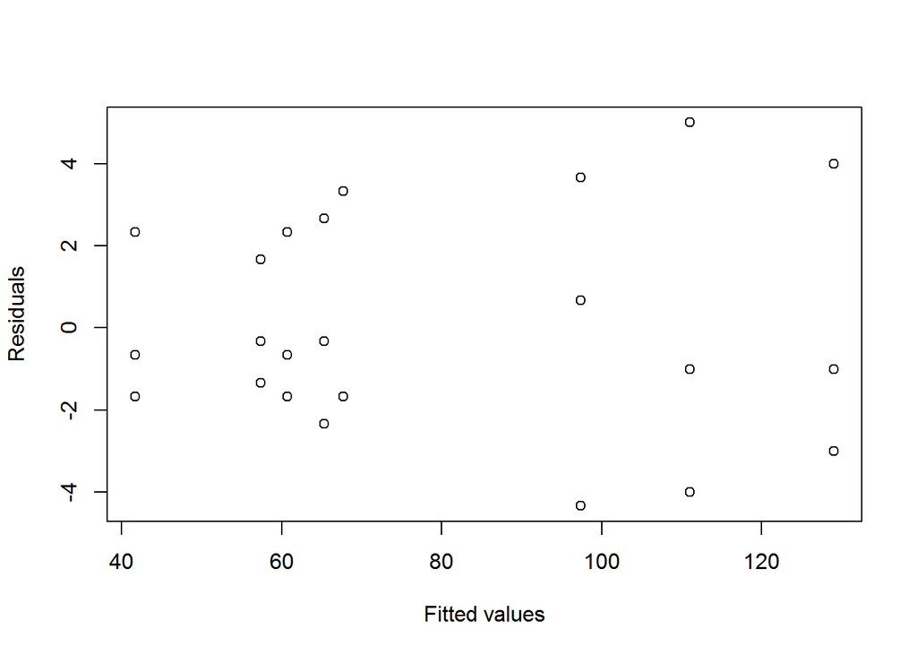

```r
plot(m1$fitted, m1$resid, xlab="Fitted values",ylab="Residuals")
```

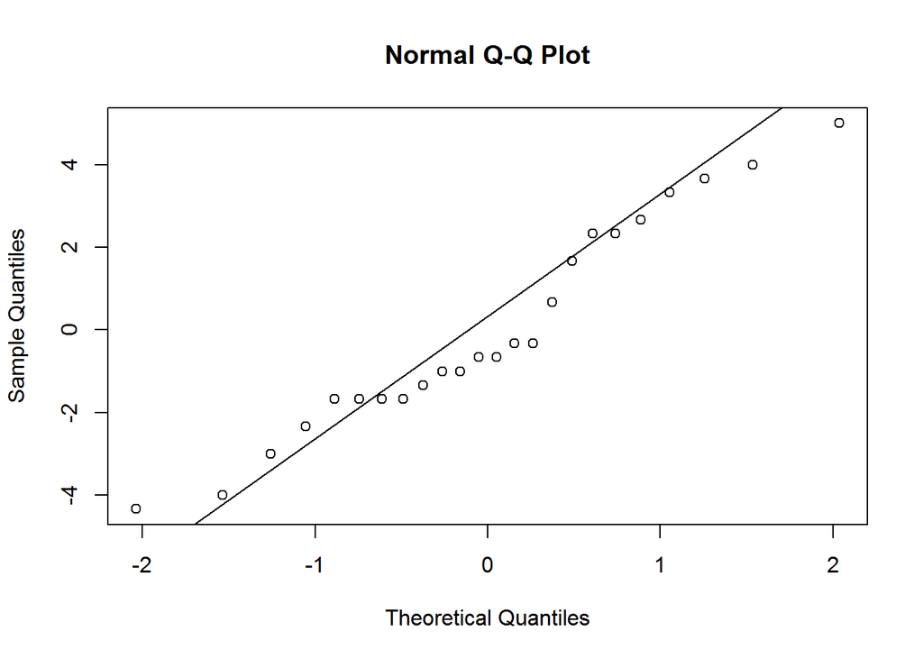

```r
qqnorm(m1$resid); qqline(m1$resid)
```

### Levene test

Create a factor that indicates which of the 8 treatment combinations each observation belongs to, and use it to do Levene’s test on the residuals (from ‘levene2.R’)

```r
source("levene2.R")
group <- method.f:type.f
levene2(m1$resid, group, method=2)
```

```
## Analysis of Variance Table
##
## Response: z
##           Df Sum Sq Mean Sq F value Pr(>F)
## group      7 10.625  1.5179  0.3195 0.9342
## Residuals 16 76.000  4.7500
##
## P-value for testing equality of variances of y's = 0.9342
```

## Model comparisons?

What is the question?

### Example 1

Is the interaction term significant?

We can see the test result form the ANOVA table of the full model (the row corresponding to `method.f:type.f`:

```r
anova(m1)
```

```
## Analysis of Variance Table
##
## Response: strength
##                 Df Sum Sq Mean Sq F value    Pr(>F)
## method.f         3  16244  5414.5 569.947 < 2.2e-16 ***
## type.f           1   1734  1734.0 182.526 3.628e-10 ***
## method.f:type.f  3   1145   381.7  40.175 1.124e-07 ***
## Residuals       16    152     9.5
## ---
## Signif. codes:  0 '***' 0.001 '**' 0.01 '*' 0.05 '.' 0.1 ' ' 1
```

Or we can do the test manually using the formula on page 37 of the notes. It is important that you all know how to do it by hand! First, we need to fit a reduced model (m1 above is the full model)—a model with no interaction:

```r
m4 = lm(strength~type.f+method.f);
anova(m4)
```

```
## Analysis of Variance Table
##
## Response: strength
##           Df Sum Sq Mean Sq F value    Pr(>F)
## type.f     1   1734  1734.0  25.402 7.271e-05 ***
## method.f   3  16244  5414.5  79.318 6.272e-11 ***
## Residuals 19   1297    68.3
## ---
## Signif. codes:  0 '***' 0.001 '**' 0.01 '*' 0.05 '.' 0.1 ' ' 1
```

```r
## Use the formula from notes page 37
SSE.f = 152;
df.f = 16;
SSE.r = 1297;
df.r = 19;

F = ((SSE.r - SSE.f)/(df.r - df.f))/(SSE.f/df.f);
F
```

```
## [1] 40.17544
```

```r
p = 1 - pf(F, df.r-df.f, df.f)
p
```

```
## [1] 1.124293e-07
```

This indicates there is strong interaction between the type effect and the method effect. In other words, the effect of method differ significantly among different types. We conclude that the the full model is preferred for this data set.

Some asked how can we extrat the SSEs from R output:

```r
## First, we have to assign the anova output to variables
a1 = anova(m1);
a4 = anova(m4);

## Then we can check the data structures.
str(a1);
```

```
## Classes 'anova' and 'data.frame':    4 obs. of  5 variables:
##  $ Df     : int  3 1 3 16
##  $ Sum Sq : num  16244 1734 1145 152
##  $ Mean Sq: num  5414.5 1734 381.7 9.5
##  $ F value: num  569.9 182.5 40.2 NA
##  $ Pr(>F) : num  1.81e-16 3.63e-10 1.12e-07 NA
##  - attr(*, "heading")= chr  "Analysis of Variance Table\n" "Response: strength"
```

```r
str(a4);
```

[output not shown]

```r
## We will see there is field named "Sum Sq", that is what we need. The quation marks are needed since there is space in the field name
a1$"Sum Sq"
```

```
## [1] 16243.5  1734.0  1145.0   152.0
```

```r
a4$"Sum Sq"
```

```
## [1]  1734.0 16243.5  1297.0
```

```r
## But we still have to figure which one (corrsponding to different rows in the ANOVA to use). For SSE, it is the last value in each case.
SSE.f = a1$"Sum Sq"[4];
SSE.r = a4$"Sum Sq"[3];

SSE.f
```

```
## [1] 152
```

```r
SSE.r
```

```
## [1] 1297
```

```r
## d.f.'s can be extracted in a similar way
a1$Df
```

```
## [1]  3  1  3 16
```

```r
a4$Df
```

```
## [1]  1  3 19
```

```r
## Since we need to it many times, we can wrap up all the calculations in R -function
F <- function(SSEr, SSEf, dfr, dff) {
  f = ((SSEr - SSEf)/(dfr-dff))/(SSEf/dff);
  p = pf(f, dfr-dff, dff, lower.tail=FALSE);

  list(f=f, p=p)

};

F(1297, 152, 19, 16);
```

```
## $f
## [1] 40.17544
##
## $p
## [1] 1.124293e-07
```

```r
## You need to do the above calculation by hand, but anova function in R will do it for us:
anova(m4, m1)
```

```
## Analysis of Variance Table
##
## Model 1: strength ~ type.f + method.f
## Model 2: strength ~ method.f * type.f
##   Res.Df  RSS Df Sum of Sq      F    Pr(>F)
## 1     19 1297
## 2     16  152  3      1145 40.175 1.124e-07 ***
## ---
## Signif. codes:  0 '***' 0.001 '**' 0.01 '*' 0.05 '.' 0.1 ' ' 1
```

### Example 2

How do I know whether the type effect is significant in any of the method group?

*We test the main effect together with the interaction effect.*

We compare the full model to a model with method effect only:

```r
m5 = lm(strength~method.f);
anova(m5);
```

```
## Analysis of Variance Table
##
## Response: strength
##           Df Sum Sq Mean Sq F value    Pr(>F)
## method.f   3  16244  5414.5  35.727 3.168e-08 ***
## Residuals 20   3031   151.6
## ---
## Signif. codes:  0 '***' 0.001 '**' 0.01 '*' 0.05 '.' 0.1 ' ' 1
```

```r
## Comparing the full and reduced models using our formula
F(3031, 152, 20, 16);
```

```
## $f
## [1] 75.76316
##
## $p
## [1] 3.439535e-10
```

```r
## Use the anova function
anova(m5, m1);
```

```
## Analysis of Variance Table
##
## Model 1: strength ~ method.f
## Model 2: strength ~ method.f * type.f
##   Res.Df  RSS Df Sum of Sq      F   Pr(>F)
## 1     20 3031
## 2     16  152  4      2879 75.763 3.44e-10 ***
## ---
## Signif. codes:  0 '***' 0.001 '**' 0.01 '*' 0.05 '.' 0.1 ' ' 1
```

Similarly, we can ask whether the method effect is significant in any of the type groups. We comapre the full model (with interaction) to a model with only type effect.

```r
m6 = lm(strength~type.f);
anova(m6);
```

```
## Analysis of Variance Table
##
## Response: strength
##           Df Sum Sq Mean Sq F value Pr(>F)
## type.f     1   1734  1734.0  2.1749 0.1545
## Residuals 22  17541   797.3
```

```r
## Comparing the full and reduced models using our formula
F(17541, 152, 22, 16);
```

```
## $f
## [1] 305.0702
##
## $p
## [1] 1.408674e-15
```

```r
## Use the anova function
anova(m6, m1);
```

```
## Analysis of Variance Table
##
## Model 1: strength ~ type.f
## Model 2: strength ~ method.f * type.f
##   Res.Df   RSS Df Sum of Sq      F    Pr(>F)
## 1     22 17541
## 2     16   152  6     17389 305.06 1.409e-15 ***
## ---
## Signif. codes:  0 '***' 0.001 '**' 0.01 '*' 0.05 '.' 0.1 ' ' 1
```